# Tiempo que consumen los alumnos de la utec en desplazarse a la universidad comparada al tiempo que le dedica a sus estudios

04 Mayo, 2023

# **Introducción**

## Relevancia

Este estudio busca evidenciar si el tiempo que consumen los alumnos en desplazarse a la universidad es considerable en comparación a las horas que le dedican a sus estudios. Además de comparar que tan cansado termina un alumno luego de un día presencial y de uno virtual. Con esta información los estudiantes podrán decidir si es que en una semana de mucha carga académica les convendría asistir al campus o quedarse en su hogar para tener más tiempo para estudiar.

## Planificación

### Realización del formulario

- Se empezó a realizar el formulario a partir de las 1:00pm y se termino a las 8:00pm.
- Los encargados en la realización del formulario son:
  - Danith Ore
  - Rodrigo Novoa
  - Angel Mora

### Análisis descriptivo

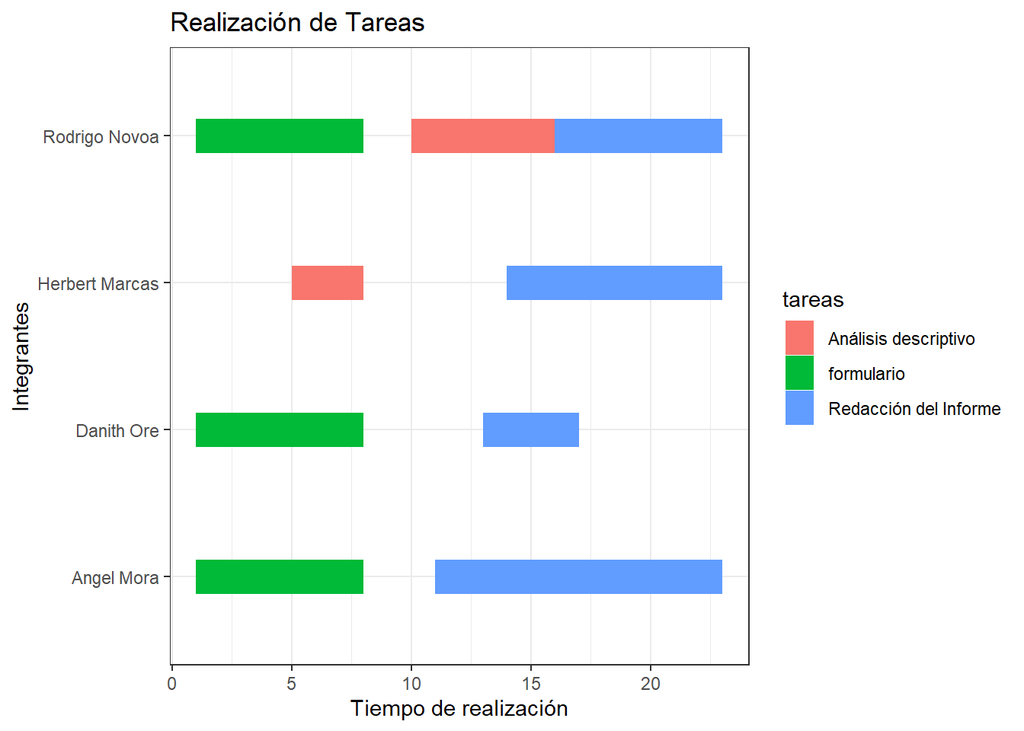

```r
tareas <-c('formulario','formulario','formulario','Redacción del Informe','Redacción del Informe','Redacción del Informe','Redacción del Informe','Análisis descriptivo','Análisis descriptivo')

integrantes <- c('Angel Mora','Danith Ore','Rodrigo Novoa','Angel Mora','Danith Ore','Rodrigo Novoa','Herbert Marcas','Rodrigo Novoa','Herbert Marcas')
start<-c(1,1,1,11,13,15,14,10,5)
end<-c(8,8,8,23,17,23,23,16,8)

data <- data.frame(integrantes,start,end,tareas)

if(!require(ggplot2)){install.packages('ggplot2')}
ggplot(data, aes(x=start,xend=end, y=integrantes, yend=integrantes, color=tareas)) + theme_bw()+
  geom_segment(size=8)+labs(title='Realización de Tareas', x='Tiempo de realización', y='Integrantes')
```

# **Datos**

## Recolección de datos

- Para la recolección de datos se ha optado por una encuesta.
  - Primero se determinaron las variables que eran relevantes para el estudio.
  - Luego se realizaron preguntas relacionadas a las variables para colocarlas en la encuesta.
  - Se compartió la encuesta a través de grupos de whatsapp y telegram.
- Se optó por usar este instrumento de recolección de información ya que resulta fácil compartirlo y el encuestado la puede llenar en cualquier momento.

## Población, muestra y muestreo

- **Población**: Todos los estudiantes de la UTEC.
- **Muestra**: Alumnos que viven en la provincia de Lima y tienen la posibilidad de asistir presencialmente al campus.
- **Unidad muestral**: Cada alumno residente en Lima que puede asistir presencialmente al campus.

## Variables

- Distrito de residencia:
  - **tipo**: cualitativa nominal.
  - **restricción**: que sea un distrito ubicado en Lima.
- Medio de transporte más utilizado:
  - **tipo**: cualitativa nominal.
  - **restricción**: que sea un medio de transporte o una forma de desplazarse a la universidad.
- Hora a la que se levanta para asistir a clases presenciales:
  - **tipo**: cuantitativa continua.
  - **restricción**: que sea una hora del día.
- Hora a la que se levanta para asistir a clases virtuales:
  - **tipo**: cuantitativa continua.
  - **restricción**: que sea una hora del día.
- Tiempo total que le toma al alumno desplazarse (ir y regresar de la universidad):
  - **tipo**: cuantitativa discreta.
  - **restricciones**: que sea un número entero positivo.
- Tiempo dedicado a los estudios diariamente:
  - **tipo**: cuantitativa continua.
  - **restricción**: que sea un número entero positivo.
- Número de días que va a la universidad semanalmente:
  - **tipo**: cuantitativa discreta.
  - **restricción**: que sea un número entero entre 0 y 6.
- Autopercepción de cansancio luego de un día presencial:
  - **tipo**:cualitativa ordinal.
  - **restricción**: que se encuentre en la escala del 1 al 10.
- Autopercepción de cansancio luego de un día virtual:
  - **tipo**:cualitativa ordinal.
  - **restricción**: que se encuentre en la escala del 1 al 10.

## Limpieza de base de datos

Importamos las librerias necesarias para pdoer realizar nuestro proyecto.

```r
library(readr)
library(dplyr)
library(stringr)
library(faraway)
```

Renombramos las variables de nuestra base de datos para que sea más entendible.

```r
DB <- read.csv('BaseDatos.csv',encoding = 'UTF-8')
DB2 <- rename(DB,Edad=Edad..en.años.cumplidos..por.ejemplo..17..22.18.etc...,Sexo=Sexo,Ciclo=Ciclo.de.estudio,Carrera=Carrera,Distrito=X.En.qué.distrito.resides.,Medio_de_transporte=X.Cuál.es.el.medio.de.transporte.que.más.utilizas.para.movilizarte.,hora_levantar_presencial=Ah.que.hora.te.levanta.para.asistir.a.tus.clases.de.forma..presencial, hora_levantar_virtual=Ah.que.hora.te.levanta.para.asistir.a.tus.clases.de.forma.virtual,Tiempo_ir_y_regresar=Tiempo.promedio.que.le.toma.ir.y.regresar.de.la.universidad.diariamente.en.minutos.,tiempo_estudio=X.Cuánto.tiempo.le.dedicas.a.tus.estudios.diariamente.,dias_que_vas_a_UTEC=Número.de.días.que.va.a.la.universidad.semanalmente,cansancio_en_clases_presenciales=Del.1.al.10.que.tan.cansado.se.siente.después.de.un.día.de.clases.presenciales..Siendo.1.nada.cansado.y.10.muy.cansado.,cansancio_en_clases_virtuales=Del.1.al.10.que.tan.cansado.se.siente.después.de.un.día.de.clases.virtuales..Siendo.1.nada.cansado.y.10.muy.cansado.
)
```

Seleccionamos las variables importantes que utilizaremos en el proyecto (quitamos las variables nombre, apellidos Y marca temporal ya que no son relevantes).

```r
DB3 <- select(DB2,Edad,Sexo,Ciclo,Carrera,Distrito,Medio_de_transporte,hora_levantar_virtual,hora_levantar_presencial,tiempo_estudio,Tiempo_ir_y_regresar,dias_que_vas_a_UTEC,cansancio_en_clases_virtuales,cansancio_en_clases_presenciales)
DB3
```

| Edad | Sexo | Ciclo | Carrera | Distrito | Medio_de_transporte | hora_levantar_virtual | hora_levantar_presencial | tiempo_estudio | Tiempo_ir_y_regresar | dias_que_vas_a_UTEC | cansancio_en_clases_virtuales | cansancio_en_clases_presenciales |
| --- | --- | --- | --- | --- | --- | --- | --- | --- | --- | --- | --- | --- |
| 18 | Mujer | 3 | Ingeniería Ambiental | BARRANCO | A pie | 10:00:00 | 9:00:00 | 150 | 20 | 5 días | 10 | 8 |
| 19 | Hombre | 3 | Ciencia de la Computación | SAN LUIS | Transporte Público | 6:30:00 | 5:30:00 | 180 | 60 | 6 días | 3 | 9 |
| 18 | Mujer | 3 | Ingeniería Ambiental | SAN JUAN DE LURIGANCHO | Transporte Público | 8:00:00 | 6:00:00 | 240 | 120 | 3 días | 3 | 8 |
| 17 | Mujer | 3 | Ingeniería Ambiental | COMAS | Transporte Público | 7:00:00 | 5:00:00 | 150 | 180 | 4 días | 7 | 9 |
| 19 | Hombre | 3 | Ingeniería Ambiental | SANTIAGO DE SURCO | Transporte Público | 7:00:00 | 4:30:00 | 120 | 110 | 2 días | 8 | 10 |
| 17 | Mujer | 3 | Ingeniería Ambiental | CARABAYLLO | Transporte Público | 6:00:00 | 7:00:00 | 240 | 240 | 2 días | 9 | 10 |
| 18 | Hombre | 3 | Ciencia de Datos | BARRANCO | Caminar | 8:00:00 | 6:00:00 | 180 | 30 | 2 días | 2 | 3 |
| 19 | Hombre | 2 | Ingeniería Mecatrónica | ANCÓN | Transporte Público | 7:00:00 | 4:00:00 | 180 | 180 | 4 días | 9 | 9 |
| 19 | Mujer | 3 | Ingeniería Industrial | SANTA ANITA | Transporte Público | 7:50:00 | 6:00:00 | 150 | 210 | 5 días | 9 | 2 |
| 20 | Mujer | 3 | Ingeniería Mecatrónica | BREÑA | Transporte Público | 6:00:00 | 6:00:00 | 60 | 20 | 1 día | 6 | 7 |

[output cut: 136 more lines]

Observamos las diferentes formas en la que los encuestados rellenaron cada pregunta y las modificamos quitando mayúsculas,minúsculas,tildes y entre otros. * Verificamos todas las respuestas de la variable Medio_de_transporte

```r
table(DB3$Medio_de_transporte)
```

```
##
##                       A pie                       A PIE
##                           2                           1
##                 Auto propio                   Bicicleta
##                           4                           1
##                     Bicleta                   Caminando
##                           1                           1
##                     Caminar                     Ninguno
##                           3                           1
##                         Pie          Transporte Público
##                           1                         102
## Tren electrico + moto = 😎 Uber, Cabify, InDriver, etc
##                           1                          28
```

- Modificamos las respuestas ya que algunas de ellas solo se diferencias por mayúsculas o son otras palabras pero con el mismo significado

```r
medioTransporte=transmute(DB3,Medio_de_transporte=case_when(Medio_de_transporte =='Caminando'~'Pie',Medio_de_transporte =='A PIE'~'Pie',Medio_de_transporte =='A pie'~'Pie',Medio_de_transporte =='Caminar'~'Pie',Medio_de_transporte =='Auto propio'~'Auto propio',Medio_de_transporte =='Bicicleta'~'Bicicleta',Medio_de_transporte =='Bicleta'~'Bicicleta',Medio_de_transporte =='Ninguno'~'Pie',Medio_de_transporte =='Tren electrico + moto = 😎'~'Transporte Público',Medio_de_transporte =='Transporte Público'~'Transporte Público',Medio_de_transporte =='Uber, Cabify, InDriver, etc'~'Uber, Cabify, InDriver, etc'))
table(medioTransporte)
```

```
## medioTransporte
##                 Auto propio                   Bicicleta
##                           4                           2
##                         Pie          Transporte Público
##                           8                         102
## Uber, Cabify, InDriver, etc
##                          28
```

```r
DB4<-data.frame(DB3$Edad,DB3$Sexo,DB3$Ciclo,DB3$Carrera,DB3$Distrito,medioTransporte,DB3$hora_levantar_virtual,DB3$hora_levantar_presencial,DB3$tiempo_estudio,DB3$Tiempo_ir_y_regresar,DB3$dias_que_vas_a_UTEC,DB3$cansancio_en_clases_virtuales,DB3$cansancio_en_clases_presenciales)
DB4
```

| DB3.Edad | DB3.Sexo | DB3.Ciclo | DB3.Carrera | DB3.Distrito | Medio_de_transporte | DB3.hora_levantar_virtual | DB3.hora_levantar_presencial | DB3.tiempo_estudio | DB3.Tiempo_ir_y_regresar | DB3.dias_que_vas_a_UTEC | DB3.cansancio_en_clases_virtuales | DB3.cansancio_en_clases_presenciales |
| --- | --- | --- | --- | --- | --- | --- | --- | --- | --- | --- | --- | --- |
| 18 | Mujer | 3 | Ingeniería Ambiental | BARRANCO | Pie | 10:00:00 | 9:00:00 | 150 | 20 | 5 días | 10 | 8 |
| 19 | Hombre | 3 | Ciencia de la Computación | SAN LUIS | Transporte Público | 6:30:00 | 5:30:00 | 180 | 60 | 6 días | 3 | 9 |
| 18 | Mujer | 3 | Ingeniería Ambiental | SAN JUAN DE LURIGANCHO | Transporte Público | 8:00:00 | 6:00:00 | 240 | 120 | 3 días | 3 | 8 |
| 17 | Mujer | 3 | Ingeniería Ambiental | COMAS | Transporte Público | 7:00:00 | 5:00:00 | 150 | 180 | 4 días | 7 | 9 |
| 19 | Hombre | 3 | Ingeniería Ambiental | SANTIAGO DE SURCO | Transporte Público | 7:00:00 | 4:30:00 | 120 | 110 | 2 días | 8 | 10 |
| 17 | Mujer | 3 | Ingeniería Ambiental | CARABAYLLO | Transporte Público | 6:00:00 | 7:00:00 | 240 | 240 | 2 días | 9 | 10 |
| 18 | Hombre | 3 | Ciencia de Datos | BARRANCO | Pie | 8:00:00 | 6:00:00 | 180 | 30 | 2 días | 2 | 3 |
| 19 | Hombre | 2 | Ingeniería Mecatrónica | ANCÓN | Transporte Público | 7:00:00 | 4:00:00 | 180 | 180 | 4 días | 9 | 9 |
| 19 | Mujer | 3 | Ingeniería Industrial | SANTA ANITA | Transporte Público | 7:50:00 | 6:00:00 | 150 | 210 | 5 días | 9 | 2 |
| 20 | Mujer | 3 | Ingeniería Mecatrónica | BREÑA | Transporte Público | 6:00:00 | 6:00:00 | 60 | 20 | 1 día | 6 | 7 |

[output cut: 136 more lines]

# **Descriptores numéricos y gráficos**

## Tiempo de estudio y tiempo de viaje

```r
summary(DB3$tiempo_estudio)
```

```
##    Min. 1st Qu.  Median    Mean 3rd Qu.    Max.
##    60.0   150.0   240.0   244.7   360.0   480.0
```

```r
summary(DB3$Tiempo_ir_y_regresar)
```

```
##    Min. 1st Qu.  Median    Mean 3rd Qu.    Max.
##    5.00   30.00   55.00   79.88  113.75  420.00
```

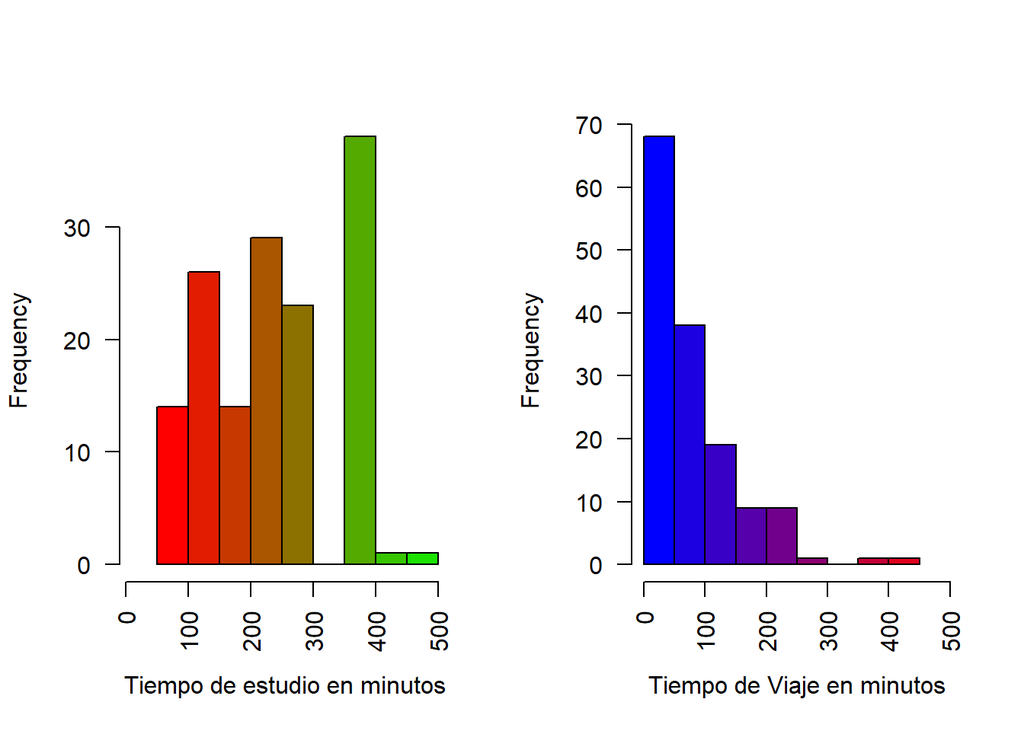

```r
par(mfrow=c(1,2))
hist(DB3$tiempo_estudio,main = " ",xlab = "Tiempo de estudio en minutos",xlim=c(10,500),las=2,col = colorRampPalette(c('red','green'))(10))
hist(DB3$Tiempo_ir_y_regresar,main=" ",xlab = 'Tiempo de Viaje en minutos',xlim =c(0,500),las=2,col = colorRampPalette(c('blue', 'red'))(10))
```

Comparando la gráfica del tiempo de estudio con la ddl tiempo de viaje se observa que la mayoría de alumnos pierde al rededor de una hora al realizar el viaje. En algunos casos esto supera el tiempo que se le dedica al estudio en un día cualquiera. En caso el alumno se encuentre en una semana cargada academicamente podría considerar ganar esa hora, al quedarse en casa y poder aprovechar el tiempo estudiando.

- hora_levantar_virtual y hora_levantar_presencial

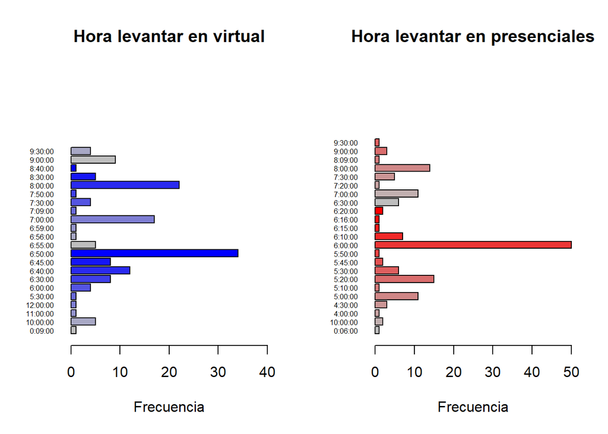

```r
library(faraway)
par(mfrow=c(1,2))
barplot(table(DB3$hora_levantar_virtual),main = "Hora levantar en virtual",xlab="Frecuencia",xlim=c(0,40),cex.names = 0.5,width = c(0.7),ylim=c(0,25),horiz = 1,las=1,col = colorRampPalette(c('gray', 'blue'))(10))
barplot(table(DB3$hora_levantar_presencial),main = "Hora levantar en presenciales",xlab="Frecuencia",xlim=c(0,50),cex.names = 0.5,width = c(0.7),ylim=c(0,25),horiz = 1,las=1,col = colorRampPalette(c('gray', 'red'))(15))
```

Estas gráficas muestran las horas a las que se levantan los alumnos en un día de clases presencial y en un día de clases virtual. Se observa que la hora a la que se levanta la mayoría de alumnos pasa de 6:00 am en presencial a 6:50 am en virtual. Esto nos dice que un alumno puede perder hasta 50 minutos de sueño en un día presencial lo cual puede llegar a afectar su energía al momento de hacer tareas y estudiar.

- Transporte

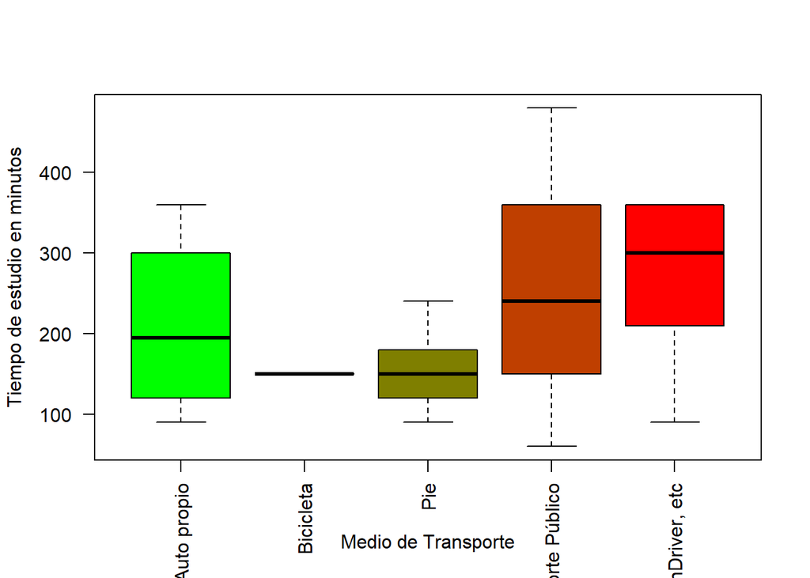

```r
boxplot(DB4$DB3.tiempo_estudio ~ DB4$Medio_de_transporte,las=2,xlab = "Medio de Transporte",ylab = "Tiempo de estudio en minutos",col = colorRampPalette(c('green', 'red'))(5))
```

```r
var(DB3$tiempo_estudio)
```

```
## [1] 9604.407
```

```r
sd(DB3$tiempo_estudio)
```

```
## [1] 98.00208
```

- Distritos

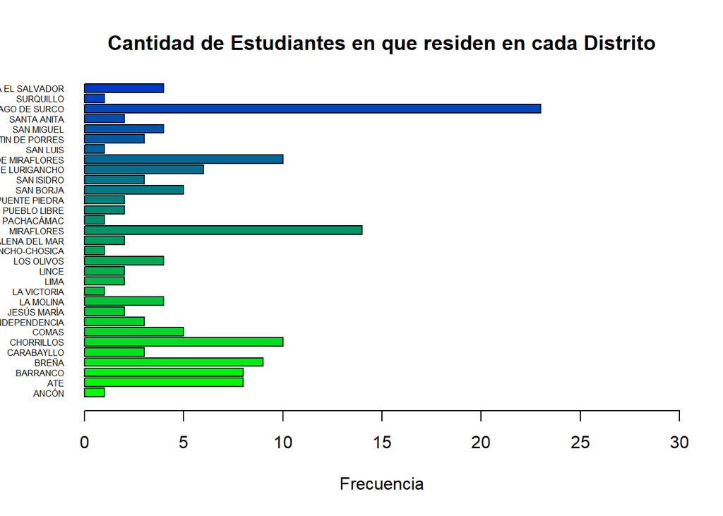

```r
barplot(table(DB3$Distrito),main = "Cantidad de Estudiantes en que residen en cada Distrito",xlab="Frecuencia",xlim=c(0,30),cex.names = 0.5,width = c(0.7),ylim=c(0,25),horiz = 1,las=1,col = colorRampPalette(c('green', 'blue'))(40))
```

```r
summary(DB3$tiempo_estudio)
```

```
##    Min. 1st Qu.  Median    Mean 3rd Qu.    Max.
##    60.0   150.0   240.0   244.7   360.0   480.0
```

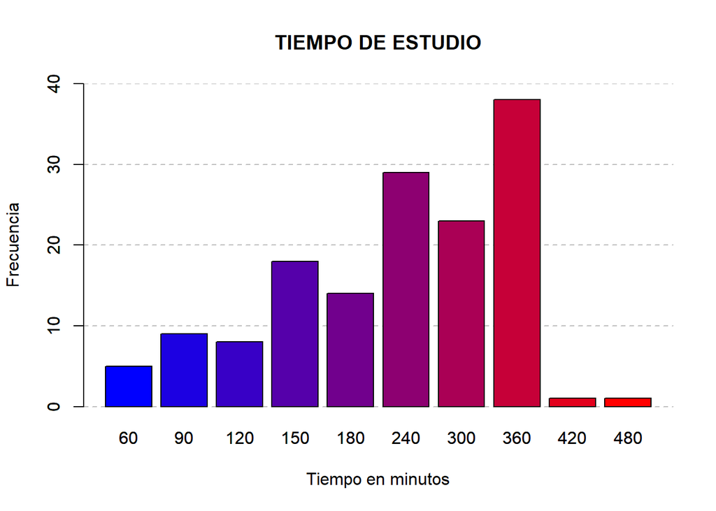

```r
barplot(table(DB3$tiempo_estudio),main = "TIEMPO DE ESTUDIO",
     xlab = "Tiempo en minutos", ylab = "Frecuencia",
     ylim=c(0,40))
grid(nx = NA, ny = NULL, lty = 2, col = "gray", lwd = 1)
barplot(table(DB3$tiempo_estudio),add=TRUE,col = colorRampPalette(c('blue', 'red'))(10))
```

Esta gráfica muestra los tiempos de estudio diario de cada alumno en minutos. Se observa que varios alumnos estudian entre 4 a 6 horas. Y que el menor tiempo dedicado es de 1 hora.

- Verificamos todas las respuestas de la variable ” Tiempo_ir_y_regresar ” en minutos

```r
summary(DB3$Tiempo_ir_y_regresar)
```

```
##    Min. 1st Qu.  Median    Mean 3rd Qu.    Max.
##    5.00   30.00   55.00   79.88  113.75  420.00
```

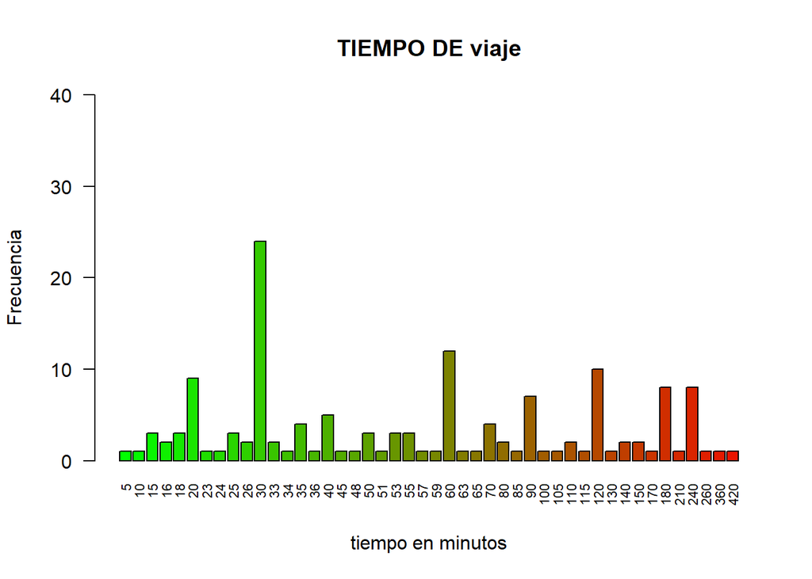

```r
barplot(table(DB3$Tiempo_ir_y_regresar),main = "TIEMPO DE viaje",xlab="tiempo en minutos",
      ylab = "Frecuencia",
     ylim=c(0,40),las=2,col = colorRampPalette(c('green', 'red'))(50),cex.names = c(0.7),width = c(0.7))
```

- distrito y tiempo de ir y regresar

[figure not shown]

```r
boxplot(DB3$Tiempo_ir_y_regresar ~ DB3$Distrito, las=2,xlab = "",ylab = "Tiempo de estudio en minutos",col = colorRampPalette(c('green', 'red'))(50))
```

- Verificamos todas las respuestas de la variable “cansancio_en_clases_virtuales”

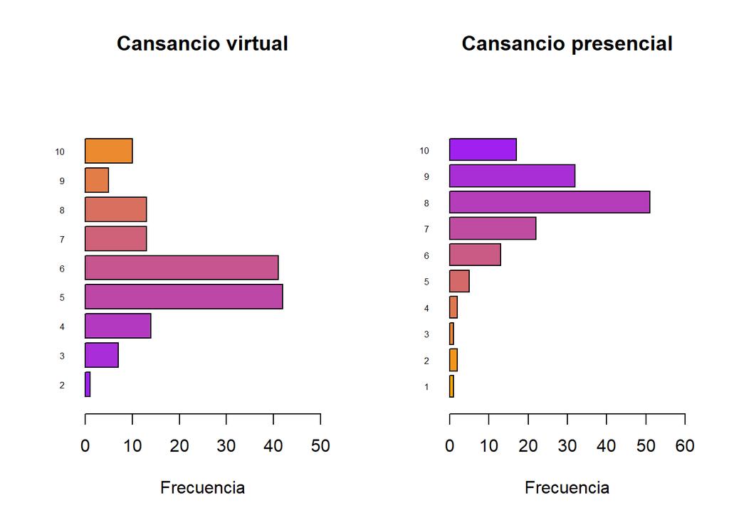

```r
par(mfrow=c(1,2))
  barplot(table(DB3$cansancio_en_clases_virtuales) ,main = "Cansancio virtual",xlab="Frecuencia",xlim=c(0,50),ylim=c(0,25),cex.names = 0.5,width = c(2),horiz =1,las=1,col = colorRampPalette(c('purple', 'orange'))(11))
barplot(table(DB3$cansancio_en_clases_presenciales),main = "Cansancio presencial",xlab="Frecuencia",xlim=c(0,60),cex.names = 0.5,width = c(1.8),ylim=c(0,25),horiz = 1,las=1,col = colorRampPalette(c('orange', 'purple'))(10))
```

Comparando las graficas de cansancio luego de un día presencial y luego de un día virtual apreciamos que la mayoría de alumnos considera que se encuentra en la escala de 5-6 es decir medianamente cansados, mientras que en un día presencial se observa como ahora la mayoría se encuentra entre 7 - 9. Esto nos indica que un alumno termina más cansado en un día presencial por factores que ya se han mencionado (el tiempo de viaje y la hora a las que se levanta ). Esta variable también entra al momento de decidir si es mejor asistir virtualmente a clases un día o una semana en la que se esté preparando para un examen o entrega importante, ya que este cansancio puede afecta en cuantas horas se trabaje y que tan bueno sea el avance

*Dias utec

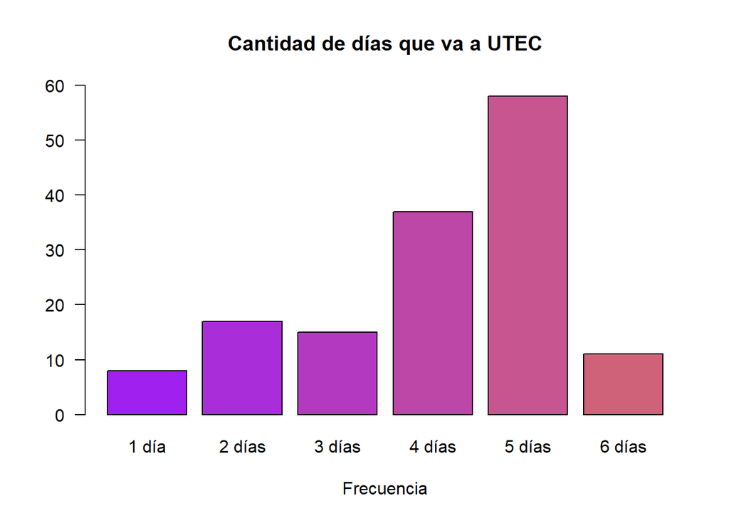

```r
barplot(table(DB3$dias_que_vas_a_UTEC),main = "Cantidad de días que va a UTEC",xlab="Frecuencia",ylim=c(0,60),width = c(2),las=1,col = colorRampPalette(c('purple', 'orange'))(11))
```